# Importing required Libraries

```python
import pandas as pd
import numpy as np
import matplotlib.pyplot as plt
import seaborn as sns
import warnings
warnings.filterwarnings('ignore')
```

```python
# read the file and display some of the data to check
df = pd.read_csv('auto-mpg.csv')
df.head(5)
```

|  | mpg | cylinders | displacement | horsepower | weight | acceleration | model year | origin | car name |
| --- | --- | --- | --- | --- | --- | --- | --- | --- | --- |
| 0 | 18.0 | 8 | 307.0 | 130 | 3504 | 12.0 | 70 | 1 | chevrolet chevelle malibu |
| 1 | 15.0 | 8 | 350.0 | 165 | 3693 | 11.5 | 70 | 1 | buick skylark 320 |
| 2 | 18.0 | 8 | 318.0 | 150 | 3436 | 11.0 | 70 | 1 | plymouth satellite |
| 3 | 16.0 | 8 | 304.0 | 150 | 3433 | 12.0 | 70 | 1 | amc rebel sst |
| 4 | 17.0 | 8 | 302.0 | 140 | 3449 | 10.5 | 70 | 1 | ford torino |

```python
# Understanding the dimensions of the dataset
df.shape
```

```
(398, 9)
```

```python
# Exploring the dataset by datatypes and null values
df.info()
```

```
<class 'pandas.core.frame.DataFrame'>
RangeIndex: 398 entries, 0 to 397
Data columns (total 9 columns):
 #   Column        Non-Null Count  Dtype
---  ------        --------------  -----
 0   mpg           398 non-null    float64
 1   cylinders     398 non-null    int64
 2   displacement  398 non-null    float64
 3   horsepower    398 non-null    object
 4   weight        398 non-null    int64
 5   acceleration  398 non-null    float64
 6   model year    398 non-null    int64
 7   origin        398 non-null    int64
 8   car name      398 non-null    object
dtypes: float64(3), int64(4), object(2)
memory usage: 28.1+ KB
```

```python
df.isnull().sum()
```

```
mpg             0
cylinders       0
displacement    0
horsepower      0
weight          0
acceleration    0
model year      0
origin          0
car name        0
dtype: int64
```

```python
df.duplicated().sum()
```

```
0
```

```python
# Knowing the unique values in features to know it is categorical or continous
df.nunique()
```

```
mpg             129
cylinders         5
displacement     82
horsepower       94
weight          351
acceleration     95
model year       13
origin            3
car name        305
dtype: int64
```

```python
# Check for wrong inputs
temp  = pd.DataFrame(df.horsepower.str.isdigit())
temp[temp['horsepower']==False]
```

|  | horsepower |
| --- | --- |
| 32 | False |
| 126 | False |
| 330 | False |
| 336 | False |
| 354 | False |
| 374 | False |

- As these won tbe shown in missing values but we need to clear this
- Because the horsepower column has numerical values but its shown as object type
- To further evaluate we nee to change it to numerical datatype.

```python
#Finding the str value
rows = [32,126,330,336,354,374]
columns = 'horsepower'
df.loc[rows,columns]
```

```
32     ?
126    ?
330    ?
336    ?
354    ?
374    ?
Name: horsepower, dtype: object
```

```python
df['horsepower'] = pd.to_numeric(df.horsepower.str.replace('?','NAN'),errors='coerce')
```

```python
df['horsepower'].isnull().sum()
```

```
6
```

```python
df['horsepower'] = df['horsepower'].fillna(df['horsepower'].median())
```

```python
df.isnull().sum()
```

```
mpg             0
cylinders       0
displacement    0
horsepower      0
weight          0
acceleration    0
model year      0
origin          0
car name        0
dtype: int64
```

```python
df.info()
```

```
<class 'pandas.core.frame.DataFrame'>
RangeIndex: 398 entries, 0 to 397
Data columns (total 9 columns):
 #   Column        Non-Null Count  Dtype
---  ------        --------------  -----
 0   mpg           398 non-null    float64
 1   cylinders     398 non-null    int64
 2   displacement  398 non-null    float64
 3   horsepower    398 non-null    float64
 4   weight        398 non-null    int64
 5   acceleration  398 non-null    float64
 6   model year    398 non-null    int64
 7   origin        398 non-null    int64
 8   car name      398 non-null    object
dtypes: float64(4), int64(4), object(1)
memory usage: 28.1+ KB
```

```python
df.describe().T
```

|  | count | mean | std | min | 25% | 50% | 75% | max |
| --- | --- | --- | --- | --- | --- | --- | --- | --- |
| mpg | 398.0 | 23.514573 | 7.815984 | 9.0 | 17.500 | 23.0 | 29.000 | 46.6 |
| cylinders | 398.0 | 5.454774 | 1.701004 | 3.0 | 4.000 | 4.0 | 8.000 | 8.0 |
| displacement | 398.0 | 193.425879 | 104.269838 | 68.0 | 104.250 | 148.5 | 262.000 | 455.0 |
| horsepower | 398.0 | 104.304020 | 38.222625 | 46.0 | 76.000 | 93.5 | 125.000 | 230.0 |
| weight | 398.0 | 2970.424623 | 846.841774 | 1613.0 | 2223.750 | 2803.5 | 3608.000 | 5140.0 |
| acceleration | 398.0 | 15.568090 | 2.757689 | 8.0 | 13.825 | 15.5 | 17.175 | 24.8 |
| model year | 398.0 | 76.010050 | 3.697627 | 70.0 | 73.000 | 76.0 | 79.000 | 82.0 |
| origin | 398.0 | 1.572864 | 0.802055 | 1.0 | 1.000 | 1.0 | 2.000 | 3.0 |

```python
df['car name'].nunique()
```

```
305
```

- We are going to drop the car name column
- It's not essential for analysis
- Cant encode or modify to significant variable
- Because its continous str variable.

```python
df.drop(columns=['car name'],axis=1,inplace=True)
```

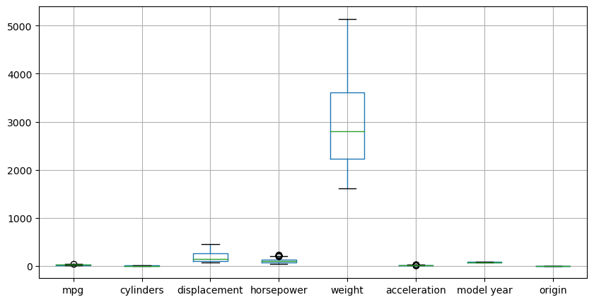

```python
# Find the outliers and need to treat them if necessary
plt.figure(figsize=(10,5))
df.boxplot()
plt.show()
```

# Visualization

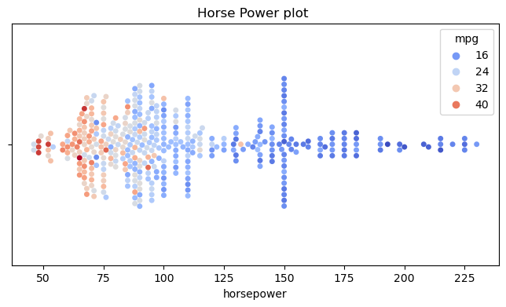

```python
# Visualing horsepower to mpg
plt.figure(figsize=(8,4))
sns.swarmplot(x=df['horsepower'],hue=df['mpg'],palette='coolwarm')
plt.title('Horse Power plot ')
plt.show()
```

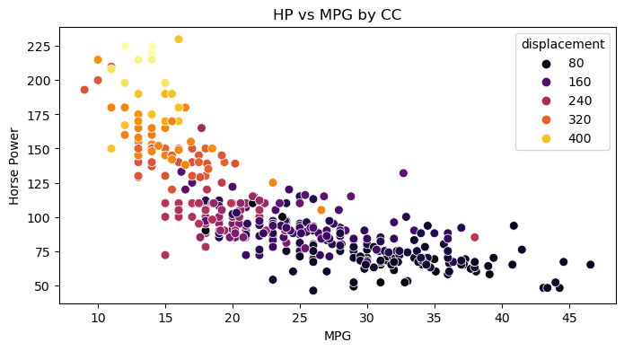

```python
plt.figure(figsize=(8,4))
sns.scatterplot(hue='displacement', y='horsepower', data=df, x='mpg', palette='inferno', s=50)
plt.title('HP vs MPG by CC')
plt.xlabel('MPG')
plt.ylabel('Horse Power')
plt.show()
```

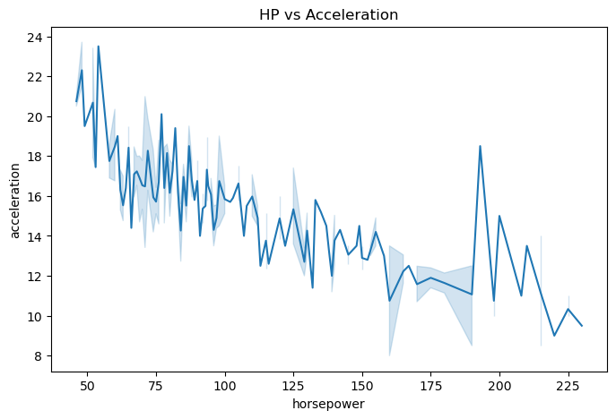

```python
plt.figure(figsize=(8, 5))
sns.lineplot(x='horsepower', y='acceleration', data=df)
plt.title('HP vs Acceleration')
plt.show()
```

### Through visualizations above you can say.

### The relationship betweeen the features.

### Directly or inversly proportions are been found.

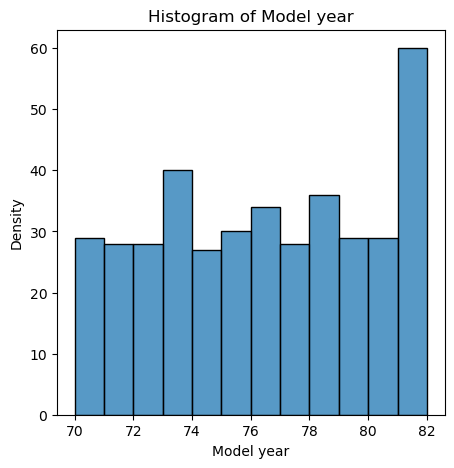

```python
# cars of different Model year
plt.figure(figsize=(5, 5))
sns.histplot(data=df, x='model year',bins=12)
plt.xlabel('Model year')
plt.ylabel('Density')
plt.title('Histogram of Model year')
plt.show()
```

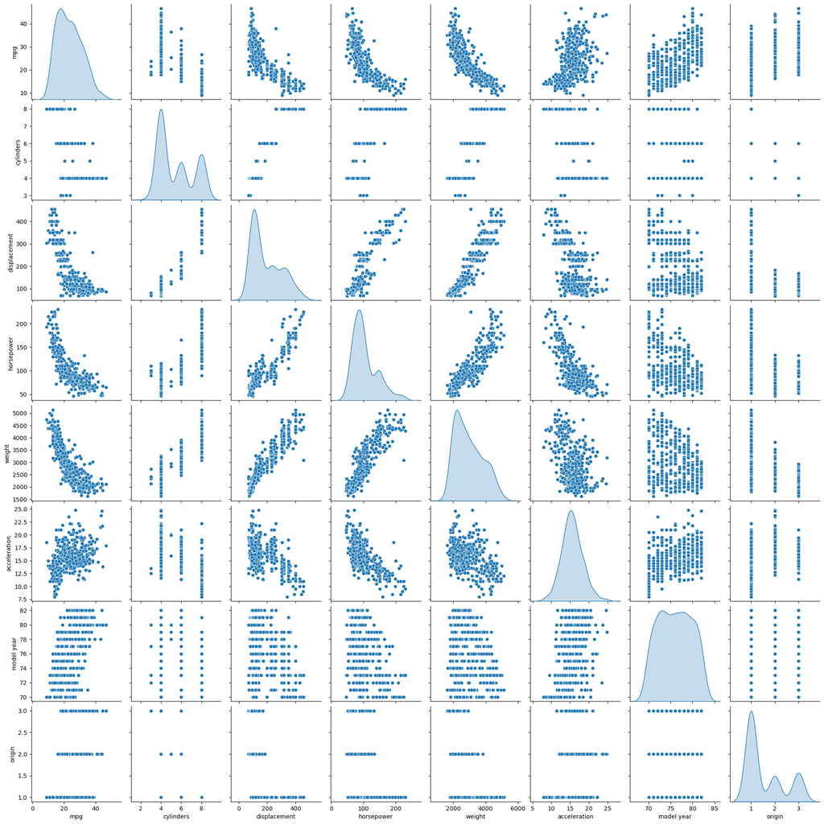

```python
# Pair plot shows the relationship and Multi-variant plots
sns.pairplot(df,diag_kind='kde')
plt.savefig('pairplot.png',dpi=300)
plt.show()
```

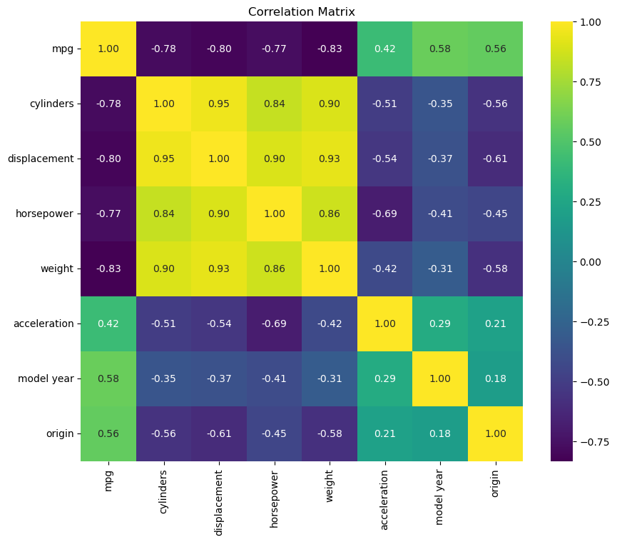

```python
# Co-relation matrix shows the relationship of variables
corr = df.corr()
plt.figure(figsize=(10, 8))
sns.heatmap(corr, annot=True, cmap='viridis', fmt='.2f')
plt.title('Correlation Matrix')
plt.show()
```

#### Weight, displacement, cyclinder and horsepower has high multi colinearity

#### We can see the Multi colinearity between the dependent variables also.

# Train & Test - Split

```python
# importing libraries and doing the train and test split
from sklearn.linear_model import LinearRegression
from sklearn.model_selection import train_test_split

X = df.drop('mpg',axis=1)
y = df[['mpg']]

X_train,X_test,y_train,y_test = train_test_split(X,y,test_size= 0.30,random_state = 1)
```

```python
#printing the shape of these splits to verify
print('X train shape: ',X_train.shape)
print('X test shape: ',X_test.shape)
print('y train shape: ',y_train.shape)
print('y test shape: ',y_test.shape)
```

```
X train shape:  (278, 7)
X test shape:  (120, 7)
y train shape:  (278, 1)
y test shape:  (120, 1)
```

```python
# Scaling the data
from sklearn.preprocessing import StandardScaler


ss=StandardScaler()


X_train.iloc[:,:] = ss.fit_transform(X_train.iloc[:,:])

X_test.iloc[:,:] = ss.transform(X_test.iloc[:,:])
```

```python
# Fitting the model
lr = LinearRegression()

lin_reg = lr.fit(X_train,y_train)
```

```python
# Let us explore the coefficient for each of the independent variable
for idx, col_name in enumerate (X_train.columns):
    print("The coefficient for {} is {}".
         format(col_name,lin_reg.coef_[0][idx]))
```

```
The coefficient for cylinders is -0.6576258418829273
The coefficient for displacement is 2.330251896461423
The coefficient for horsepower is -0.7459683255585576
The coefficient for weight is -5.946105977233697
The coefficient for acceleration is 0.16973210125549099
The coefficient for model year is 2.9241345021479934
The coefficient for origin is 0.9598668889216055
```

```python
# Intercept value
intercept = lr.intercept_[0]
print("The intercept for our model is {}".format(intercept))
```

```
The intercept for our model is 23.600719424460433
```

```python
y_train_pred = lr.predict(X_train)
```

```python
y_test_pred = lr.predict(X_test)
```

```python
lr.score(X_train,y_train)
```

```
0.8081802739111359
```

```python
lr.score(X_test,y_test)
```

```
0.8472274567567306
```

# Model Performance Measure

```python
#comparing predicted values with actual values of train dataset
from sklearn.metrics import r2_score
r2_score_train = r2_score(y_train,y_train_pred)
r2_score_train*100
```

```
80.81802739111359
```

```python
#comparing predicted values with actual values of test dataset
r2_score_test = r2_score(y_test,y_test_pred)
r2_score_test*100
```

```
84.72274567567307
```

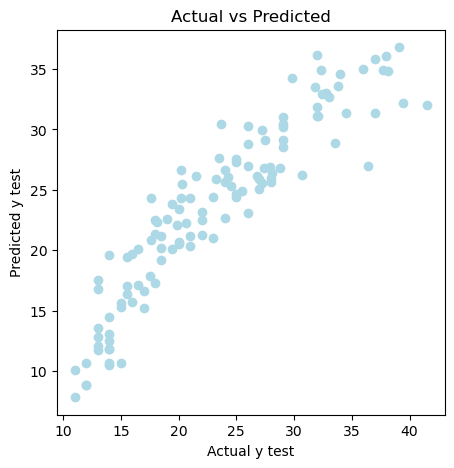

```python
# Visualizing the Actual vs predicted model
plt.figure(figsize=(5, 5))
plt.scatter(x=y_test, y=y_test_pred, color='lightblue')
plt.xlabel('Actual y test')
plt.ylabel('Predicted y test')
plt.title('Actual vs Predicted')
plt.show()
```

# Inference:

- The above plot show the linearity between actual and predicted shows the linear regression is successfull.
- Visualizations and plots shows the relationship between the features.
- We checked for duplicates and missing values for Data Cleaning.
- We Noticed the numerical column is in object data type by df.info() function.
- Checked for the unreal value and replaced with null and filled with median value.
- Splitted to train and test split to train and test the data for regression model.
- Scaled the data before fitting so that model would be easy and confident to predict the datas.
- Fitting the train data to model and got the score of 80% confident .
- Proceeded to test and predicted it and showed 84% confident score (R2 score).
- Visualized the y -(actual and predicted)
- Linearity is shown by scartter plot.
- So, This model would predict the MPG of cars with these features present with 80-84% Confidence. *
- Important note:

  ```
  *   May this model be 80% confident by we can further tune and get high R2 score.
  *   Follow me on linkdin for future updates : Jeevarathnam R T , URL : www.linkedin.com/in/jeeva46DA
  ```